# Combination of field and experimental data together with computational models reveal cognitive mechanisms behind cleaner fish behaviour

Andrés E. Quiñones

1

Zegni Triki

2

Redouan Bshary

1

Abstract

While it is generally straightforward to quantify individual performance in cognitive experiments, identifying the underlying cognitive processes remains a major challenge. Often, different mechanistic underpinnings may yield similar performances, and Lloyd Morgan’s cannon warrants acceptance of the simpler explanation. Alternatively, when the different mechanisms interact with environmental conditions, variation in performance across environments might allow to statistically infer the mechanism responsible. However, to do this it is necessary to have quantitative predictions for the different candidate mechanisms. Here, we use a set of computational models to get quantitative predictions from alternative learning mechanisms, and using Bayesian statistics fit the model parameters to performance data. We used experimental data on performance in an ephemeral reward task by wild-caught cleaner fish Labroides dimidiatus, as well as cleaner and client fish densities from the locations of capture. The task can in principle be solved by estimating future consequences of an action, or by perceiving the removal of the ephemeral reward as psychological punishment (negative reinforcement). We found that a model where cleaners only estimate the future consequences of their actions explains best which cleaner relative abundances cause the fish to develop a preference for an ephemeral food source. This model also yields performances that can be considered the result of locally optimal decision-rules, in contrast to the negative reinforcement model. We argue that the combination of computational models with data is a powerful tool to infer the mechanistic underpinning behind cognitive performance.

## Introduction

Recent research on the cognitive tool kit needed to solve an ephemeral reward task has used a broad approach as proposed by Shettleworth (2009), who defined cognition as includes all ways in which animals take in information through the senses, process, retain and decide to act on it. Indeed, perception of relevant cues is of major importance for individual performance; i.e. what relevant information is encoded in the design of the two plates (colour versus size; (Wismer et al. 2019)), or whether the information is in the colour of the food (Prétôt et al. 2021; Prétôt, Bshary, and Brosnan 2016a), and whether the food is visible or hidden/released only when the subjects made choices on a touch screen (Prétôt, Bshary, and Brosnan 2016b). However, identifying cues as salient is not the only challenge of the ephemeral reward task, as revealed by proximate learning models. Such models allow varying the cognitive tool kit and to evaluate which minimal kit is necessary to solve the task at hand (e.g. (Dubois et al. 2021)). Applied to the ephemeral reward task, learning models showed that basic reinforcement learning does not suffice to solve the task (Prat, Bshary, and Lotem 2022; Quiñones et al. 2019). This is particularly so when models assume the more complex natural situation in which cleaners not only face resident-visitor pairs but also visitor-visitor and resident-resident pairs, as well only a resident or only a visitor. To be able to give visitors priority over residents, cleaners need to be able to assess a client’s value separately for the three possible forms of encounter (alone, paired with a fish with the same strategic option, paired with a fish with the alternative strategic option) (Quiñones et al. 2019). The ability to keep such separate scores for the same stimulus has been termed configurational learning, or chunking, or segmentation (see references in Prat, Bshary, and Lotem (2022)).

To solve the ephemeral reward task, cleaners also need to account for the future consequences of current decisions. In the model by Quiñones et al. Quiñones et al. (2019), this could be achieved in two non-mutually exclusive ways: through low temporal discounting of future effects, also termed ‘chaining’ (Enquist, Lind, and Ghirlanda 2016); and/or through perceiving a visitor client leaving as psychological punishment (i.e. as a negative reinforcer). Given that a negative reinforcer is part of the ubiquitous learning mechanism termed operant conditioning (Thorndike 1898; Skinner 1938), this explanation could be considered the simpler one. Furthermore, accounting for the future effects of an action is considered an advanced cognitive ability (Suddendorf and Corballis 2007). Thus, standard logic of Lloyd Morgan’s cannon demands that operant conditioning as the simpler explanation is to be accepted by default. Here, we explore the possibility that fitting a model in which the action of these two mechanisms, operant conditioning and chaining, depends on model parameters may reveal which process cleaners actually use. This is because one process may be better at predicting the observed variation in cleaner fish performance as a function of ecological conditions.

Various repetitions of the ephemeral reward task in different years and with cleaners caught from various locations around Lizard Island, Great Barrier Reef, revealed that cleaner and client densities in nature affect how cleaners perform in the original market task: when relative densities are low, cleaners are more likely to fail to complete the task (Triki et al. 2019, 2018; Wismer et al. 2014). The explanation for this pattern is twofold. First, low cleaner abundances implies low supply and high demand of cleaning services. Under this conditions, there will be less occasions under which failing to give priority to a visitor translates to an empty cleaning station. Secondly and also related to the state of the cleaning market, visitor clients are less likely to exert their choice options (and hence wait for inspection if made to wait) when cleaner fish densities are low (Triki et al. 2020). If visitors are not choosy, cleaners should not give them priority anymore. Thus, the underling cognitive machinery and ecological variables apparently interact to produce such variable performance. By fitting our model to the empirical data on fish densities and cleaner fish performance in the ephemeral reward task we aimed to address two questions. First, we aimed to determine the likely mechanism used by cleaners to incorporate future consequences of current decisions by testing whether operant conditioning, chaining, or a combination of both best explains performance. Second and related to the first question, we aimed to determine whether the two mechanisms differed with respect to the ecological conditions that are likely to cause high versus low performance in the ephemeral reward task. If that were the case, we would assess which mechanism would yield more appropriate performance patterns. Relying on the logic of biological market theory, we predicted that appropriate performance is to show low preference for visitors under high local client-to-cleaner ratio as visitor leaving rates should be low and any leaving visitor will be readily replaced by another client. In contrast, cleaners should show high performance if the local client-to-cleaner ratio favours clients.

## Methods

### Overview

We used the data from (Triki et al. 2019) to fit the parameters of the model analysed in (Quiñones et al. 2019). For the bayesian fitting procedure we used Markov Chain Monte Carlo (MCMC) with a Metropolis sampler to estimate the posterior distribution of the model parameters. The data consist a of the number of times that a set of cleaners chose to feed of a visitor client plate in the context of the market task. This set of cleaners were collected in different locations and in each one of those locations environmental variables were measured. These environmental variables recorded from each location are used as input for the computational model. Given these inputs, the computational model produces a time series of choices in the market task. In the model the preference for the two options changes as the algorithm learns based on the reward that the two options provide. Thus, we run the model for 10000 steps and use the last 3000 steps as the preference developed in the model for visitors given the environmental variables. We use this preference as the predicted probability in a binomial distribution to calculate the likelihood that the number of visitor choices obtained from each cleaner is generated by the model. We sum over all the cleaners the log-likehoods and use the total for the acceptance of new parameters in the MCMC.

### The model

The model consist of a set individual-based simulations where individuals face a series of choices between two options. Individuals in the model represent cleaners, and the options they face simulate the natural conditions of a cleaning market. Thus, individuals in the model choose to prioritize different clients. These clients are classified as resident and visitors. Residents are those clients that stay in the cleaning queue when they are not given priority; while visitors leave the queue (with a certain probability) after they are not given priority. Individuals obtain a fixed reward from cleaning a client regardless of the type. Every time individuals face and make a choice they update the probability of making that same choice. The update is based on the difference between the expectation of reward and the actual reward the individual obtains (prediction error) (Sutton and Barto 2018; Rescorla and Wagner 1972); and it is carried in the direction that would lead to more reward being obtained, given the new information. Further details of the model implementation can be found in the paper (Quiñones et al. 2019). The model analysis points to the relevance of two parameters. First, $\gamma$ measures how much individuals include future rewards in their decision updates. If $\gamma=0$, individuals only use the immediate reward obtained from a cleaning interaction. As $\gamma$ increases individuals include more the reward obtained from the subsequent choices. That amounts to calculating and using for decision making the future expected rewards in action. Second, $\eta$ measures how much individuals include in their reward the fleeing behaviour of visitor clients as a negative component. Both of these parameters allow individuals to use in their estimates the future effects of their choices. The model analysis by Quiñones *et al* (Quiñones et al. 2019) shows that without either of them, learning individuals cannot develop a preference for the visitor client. The analysis contrast the effect of these two parameters against variation in the relative abundance of the two client types. The analysis shows that under very high client (relative) abundance the presence of future rewards ($\gamma>0$) no longer favours the preference for the ephemeral clients, this effect does not occur with negative reward mediated by client behaviour ($\eta$). Thus, the analysis suggests that future reward as an explanation for cleaner ability to prefer visitors is supported by Triki *et al* (Triki et al. 2019) data. However, a combination of future and negative rewards, could still be a better explanation for the data. In the current analysis, we will use the data from (Triki et al. 2019) to fit some of the model parameters, particularly relevant we will fit $\gamma$ and $\eta$ to find out whether each or a combination of these effects is a better explanation for the pattern seen in the data. For other parameter values used for the model simulations and the MCMC see Table

### Data explanation

In order to capture with the model the relationship between the characteristics of the market (environment) and the cleaner’s performance we need to translate the absolute abundances of the data to to a measure of relative abundances that captures client visitation patterns. This is because in the model, relative abundances of clients define not only the probability of residents and visitors, but also how often the cleaning station is empty (e.g. there are no clients to be cleaned). The more cleaners there are, the more options are available for the clients and hence the higher is the probability of empty cleaning stations. How often the cleaning stations are empty in turns influences the value that cleaners can expect from their choices. The emptier the cleaning stations are, the more beneficial it is to prioritize a client that will not stay. However, the frequency of empty spots in the cleaning station does not only depend on cleaner abundances but also on the frequency with which clients visit the station. The client visitation frequency will likely vary among different clients depending on parasite abundances and loads. These are variables for which we do not have field estimates. Thus, we computed a measure of relative cleaner abundance for each site relative to absolute abundances and multiplied by a scaling constant that changes the range of the variable. This scaling constant is meant to capture variation in the market conditions driven partly by cleaner abundance. We fit the value of the scaling constant as part of the statistical inference. As for the client abundances for residents and visitors we computed a relative measure with respect to the total client abundance, and weighted that by the rescaled relative absence of cleaners (1-relative cleaner abundance). Thus, all three measures of relative abundance sum up to 1, and can be used in the model as a proxy for the probability of having different options in the cleaning station.

## Results

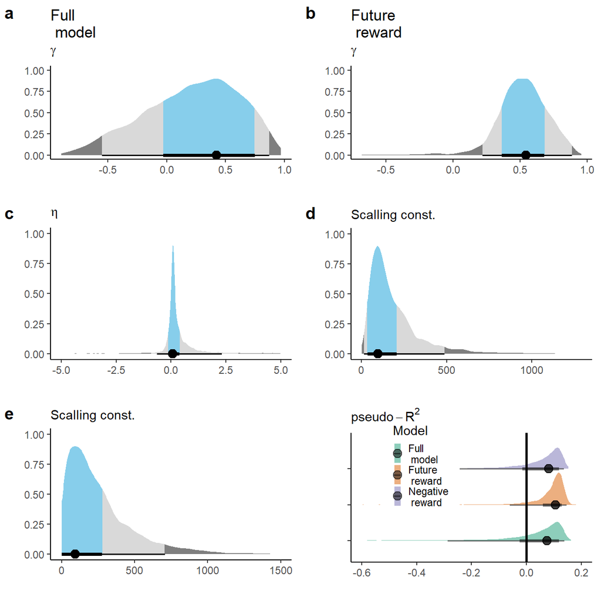

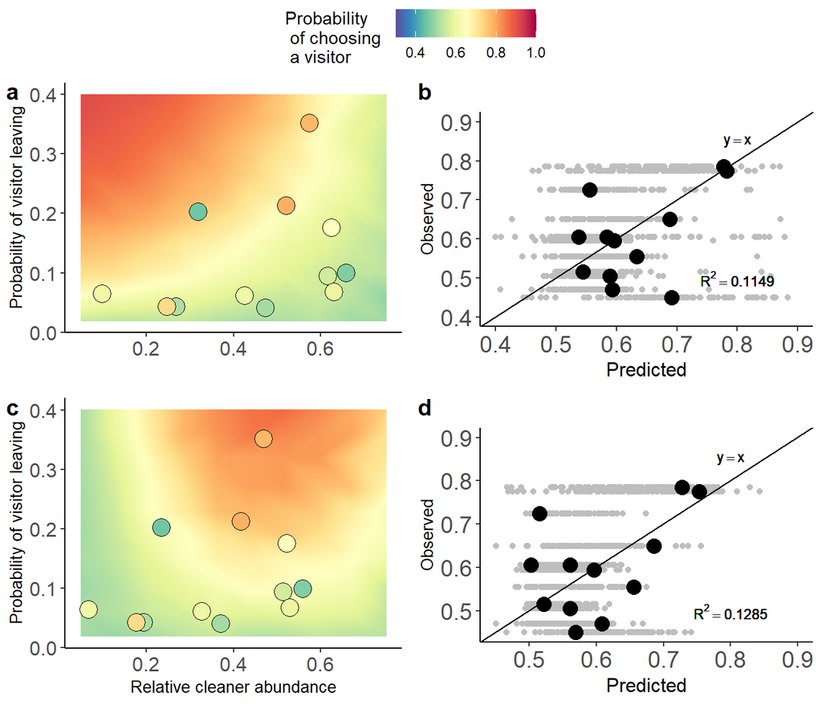

Observed and predicted probability of choosing a visitor. Left-hand side panel: color contour shows the prediction of the learning model using the mode of the posterior distributions of parameters recovered by the statistical analysis. Dots show the frequency of visitor choices for the 12 locations, as well as the corresponding relative cleaner abundance (x axis) and frequency of visitors leaving the station (y axis). Right-hand side panels: scatter plot of the observed and predicted probabilities of choosing a visitor for 12 locations. Line correspond to a perfect match between observed and predicted probabilities. Pseudo $R^2$ shown in the lower right corner corresponds to the fit of a model parameterized with the mode of the posterior distributions. Upper panels show prediction from a model including future and negative reward, lower panels froma model with only future reward.

The main reason for negative and future reward to give different predictions is the way that cleaner’s relative abundance influences the preference for the visitor clients. Visitor leaving probability has a similar positive effect on the probability of choosing the visitor clients on all three models (Fig. , ). In contrast, cleaner’s relative abundance has a different effect in the model with only future reward, compared to the other two. In the model with only future reward only intermediate cleaner abundance triggers a preference for the visitor clients (Fig. c). In models with negative reward, both intermediate and low cleaner abundance trigger a preference for the visitor. (Fig. a, ).

## Discussion

We have shown that using future rewards in the learning process is the cognitive strategy that best explains the intra-specific variation in cleaner performance in the market task. We compared future reward with the use of visitors behaviour as a primary source of negative reward, and a combination of both. All three models capture well the positive relation between visitor leaving behaviour and cleaner performance in the market task (Triki et al. 2019). For both mechanisms it is indeed necessary to have fleeing behaviour on the side of the visitors for cleaners to develop a preference for them. The key difference between future and negative reward emerges in the predicted relation between cleaner relative abundance and cleaner performance. When cleaner relative abundance is low a model with only future reward predicts low performance in the market task regardless of the visitor leaving probability. In contrast, a model with negative reward predicts the highest performance with low relative cleaner abundance, particularly together with high probability of visitor leaving (Fig. ). Low cleaner abundances mean the market has an excess of demand for cleaning services. In the model, this translates to a cleaning station that is frequently full. Thus, when visitors leave, it’s likely that the cleaner will have access to another client, and there will not be much difference in future reward between choosing a visitor and a resident. Thus, estimation of future reward will not develop a preference for the visitor in this conditions, because it matches the state of the market. On the other hand, the effect of negative reward is unaffected by this market situation. In a full station, cleaners will get more often the heterotypic (resident-visitor) option and will develop a preference for the visitor faster. Note that when cleaner abundance is high situations with a resident and a visitor will be so rare that neither mechanism will be very efficient in generating a preference for visitors. When such choice arises it is still be best to choose the visitor; however, the learning machinery will not be able to develop this preference efficiently. Overall, estimation of future reward is then the cognitive mechanism that allows cleaners to adaptively respond conditions to the ecological conditions of the biological market.

The cognitive mechanism that our analysis highlights does not require a direct flow of information between the cleaner and its social environment. The adaptive responses to local conditions in cleaners is not only evidenced by their performance in experiments, but also by changes in their brain anatomy. Indeed, individual cleaners that performed in the laboratory test according to what is best at the location in which they were caught had larger forebrains harbouring more cells than individuals whose performance mismatched locally optimal decision-rules (Triki et al. 2020). This suggests that despite the overall behavioural adjustment, evidenced here and elsewhere (Triki et al. 2019, 2018), there are some cleaners better than others at adjusting their behaviour. Triki *et al.* (Triki et al. 2020) refer to these as socially competent cleaners. Social competence refers to the ability to optimise social behaviour depending on the available social information (Taborsky and Oliveira 2012; Bshary and Oliveira 2015). However, we have shown here that cleaners are able to adjust their preference according to the social environment without using any direct information about the social environment. Instead cleaners seem to adjust their preference using information from the visitation patterns of their clients. These patters are of course determined by the feedback with the cleaner’s social environment (relative abundance). Our models, however, do not include the possibility of cleaners responding to their relative abundance directly. The mechanism we present is a general way to learn from the environment in both asocial and social situations. It would be interesting to contrast this learning mechanism with one tailored to a social situation, and see whether such mechanism fits the data better. More generally, an important challenge ahead is to understand which cognitive mechanisms evolved exclusively for social life.

One potential difference between cleaners that adjusted adaptively, like the ones reported in Triki *et al.* (Triki et al. 2020), is configurational learning or chunking. The original analysis of the learning model showed that agents needed two mechanism to solve the market task; to account for the future, and to assign value to the combination of clients present in the station (Quiñones et al. 2019). The latter is referred to as configurational learning or chunking (Sutherland and Rudy 1989; Miller 1956). Theoretical models suggest that the lack of configurational learning is related to a low frequency with which stimuli are encountered together (Kolodny, Edelman, and Lotem 2014; Prat, Bshary, and Lotem 2021). Thus, cleaner relative abundance could be related to this mechanisms as well. Given that the lack of either of these two mechanisms yields neutral preferences (Quiñones et al. 2019), we can’t, based on the current analysis, distinguish between the two possibilities. One potential way to distinguish between the two would be to use an experimental set up designed to test configuration learning on cleaners with high and low performance in the market task (Woodbury 1943; Sutherland and Rudy 1989).

Combining mechanistic modelling with empirical data provides a powerful tool to identify the cognitive processes underlying learning in animals. The combination overcomes the limitations of the general philosophy in animal cognition to apply the logic of Lloyd Morgen’s canon (Occam’s razor). Excluding basic reinforcement learning explanations (operant and/or classical conditioning) as a potential explanation in experiments often warrants animals solving the task on the first possible occasion. For example, any theory of mind task needs to be solved in the first trial in order to exclude fast conditioning (Heyes 1998). Similarly, subjects need to solve a social learning task on the first trial to accept imitation as a mechanism over stimulus/local enhancement. Such strict conditions are virtually never met. For example, potato washing by Japanese macaques, an iconic example of social learning, took several years to spread within the group (Kawamura 1959), meaning that any learner had been repeatedly exposed to demonstrations before acquisition. Importantly, Galef (Galef 1992) refuted imitation as mechanism not simply because of the repeated exposure but because a (rather qualitative) analysis of the spread of potato washing across individuals did not follow the prediction based on imitation learning (see also (Hirata, Watanabe, and Masao 2001)). In our case, the number of trials it took cleaners to learn the solution to the market task would never allow to exclude an important role of negative reinforcement based on the data alone. However, fitting model predictions to our data set revealed that a more complex mechanism (estimation of future reward) fits the data better.

# Supplementary material

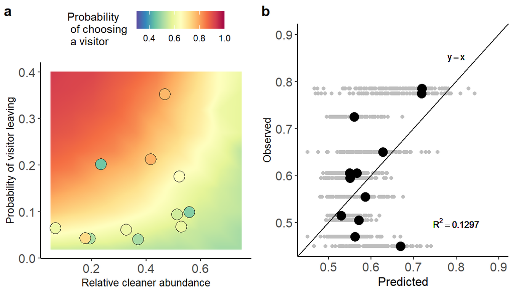

Observed and predicted probability of choosing a visitor for a model without future rewards. Left-hand side panel: color contour shows the prediction of the learning model using the mode of the posterior distributions of parameters recovered by the statistical analysis. Dots show the frequency of visitor choices for the 12 locations, as well as the corresponding relative cleaner abundance (x axis) and frequency of visitors leaving the station (y axis). Right-hand side panel: scatter plot of the observed and predicted probabilities of choosing a visitor for 12 locations. Line correspond to a perfect match between observed and predicted probabilities.

Parameter values with which the model was run in the MCMC. $\sigma$ refers to the amplitud of the perturbation kernel with the subscript indicating the associated parameter. New values were taken from a uniform distribution. $\alpha$ refers to the learning rate.

| Parameter | Value |
| --- | --- |
| Learning rounds | 10000 |
| Reward value | 1 |
| $\alpha$ | 0.05 |
| $\sigma_{\gamma}$ | 0.3 |
| $\sigma_{\eta}$ | 4 |
| $\sigma_{Sca.Const.}$ | 300 |
| Number of chains | 5 |
| Chain lenght | $1^5$ |

Bshary, Redouan. 2001. “The Cleaner Fish Market.” In *Economics in Nature: Social Dilemmas, Mate Choice and Biological Markets*, edited by Jan A. R. A. M. Van Hooff, Peter Hammerstein, and Ronald Noë, 146–72. Cambridge: Cambridge University Press. https://doi.org/10.1017/CBO9780511752421.010.

Bshary, Redouan, and Alexandra S Grutter. 2002. “Asymmetric Cheating Opportunities and Partner Control in a Cleaner Fish Mutualism.” *Animal Behaviour* 63 (3): 547–55. https://doi.org/10.1006/anbe.2001.1937.

Bshary, Redouan, and Rui F Oliveira. 2015. “Cooperation in Animals: Toward a Game Theory Within the Framework of Social Competence.” *Current Opinion in Behavioral Sciences*, Social behavior, 3 (June): 31–37. https://doi.org/10.1016/j.cobeha.2015.01.008.

Bshary, Redouan, and Daniel Schäffer. 2002. “Choosy Reef Fish Select Cleaner Fish That Provide High-Quality Service.” *Animal Behaviour* 63 (3): 557–64. https://doi.org/10.1006/anbe.2001.1923.

Dubois, Thibault, Cristian Pasquaretta, Andrew B. Barron, Jacques Gautrais, and Mathieu Lihoreau. 2021. “A Model of Resource Partitioning Between Foraging Bees Based on Learning.” *PLOS Computational Biology* 17 (7): e1009260. https://doi.org/10.1371/journal.pcbi.1009260.

Enquist, Magnus, Johan Lind, and Stefano Ghirlanda. 2016. “The Power of Associative Learning and the Ontogeny of Optimal Behaviour.” *Royal Society Open Science* 3 (11): 160734. https://doi.org/10.1098/rsos.160734.

Galef, Bennett G. 1992. “The Question of Animal Culture.” *Human Nature* 3 (2): 157–78. https://doi.org/10.1007/BF02692251.

Grutter, A. S. 1995. “Relationship Between Cleaning Rates and Ectoparasite Loads in Coral Reef Fishes.” *Marine Ecology Progress Series* 118 (March): 51–58. https://doi.org/10.3354/meps118051.

Grutter, and A. S. 1995. “Relationship Between Cleaning Rates and Ectoparasite Loads in Coral Reef Fishes.” *Marine Ecology Progress Series* 118 (March): 51–58. https://doi.org/10.3354/meps118051.

Heyes, C. M. 1998. “Theory of Mind in Nonhuman Primates.” *Behavioral and Brain Sciences* 21 (1): 101–14. https://doi.org/10.1017/S0140525X98000703.

Hirata, Satoshi, Kunio Watanabe, and Kawai Masao. 2001. “‘Sweet-Potato Washing’ Revisited.” In *Primate Origins of Human Cognition and Behavior*, edited by Tetsuro Matsuzawa, 487–508. Tokyo: Springer Japan. https://doi.org/10.1007/978-4-431-09423-4_24.

Johnstone, R. A., and R. Bshary. 2008. “Mutualism, Market Effects and Partner Control.” *Journal of Evolutionary Biology* 21 (3): 879–88. https://doi.org/10.1111/j.1420-9101.2008.01505.x.

Kawamura, Syunzo. 1959. “The Process of Sub-Culture Propagation Among Japanese Macaques.” *Primates* 2 (1): 43–60. https://doi.org/10.1007/BF01666110.

Kolodny, O., S. Edelman, and A. Lotem. 2014. “The Evolution of Continuous Learning of the Structure of the Environment.” *Journal of The Royal Society Interface* 11 (92): 20131091–91. https://doi.org/10.1098/rsif.2013.1091.

McFadden, Daniel. 1974. “Conditional Logit Analysis of Qualitative Choice Behavior.” *Frontiers in Econometrics*, Frontiers in econometrics. - New York [u.a.] : Academic Press, ISBN 0-12-776150-0. - 1974, p. 105-142,.

Miller, George A. 1956. “The Magical Number Seven, Plus or Minus Two: Some Limits on Our Capacity for Processing Information.” *Psychological Review* 63 (2): 81.

Noë, Ronald, and Peter Hammerstein. 1994. “Biological Markets: Supply and Demand Determine the Effect of Partner Choice in Cooperation, Mutualism and Mating.” *Behavioral Ecology and Sociobiology* 35 (1): 1–11. https://doi.org/10.1007/BF00167053.

———. 1995. “Biological Markets.” *Trends in Ecology & Evolution* 10 (8): 336–39. https://doi.org/10.1016/S0169-5347(00)89123-5.

Pepperberg, Irene M., and Leigh Ann Hartsfield. 2014. “Can Grey Parrots (Psittacus Erithacus) Succeed on a "Complex" Foraging Task Failed by Nonhuman Primates (Pan Troglodytes, Pongo Abelii, Sapajus Apella) but Solved by Wrasse Fish (Labroides Dimidiatus)?” *Journal of Comparative Psychology (Washington, D.C.: 1983)* 128 (3): 298–306. https://doi.org/10.1037/a0036205.

Prat, Yosef, Redouan Bshary, and Arnon Lotem. 2021. “A Role for Ecologically-Tuned Chunking in the Evolution of Advanced Cognition Demonstrated by Modelling the Cleaner Fish Market Problem,” May, 2021.05.30.446324. https://doi.org/10.1101/2021.05.30.446324.

———. 2022. “Modelling How Cleaner Fish Approach an Ephemeral Reward Task Demonstrates a Role for Ecologically Tuned Chunking in the Evolution of Advanced Cognition.” *PLOS Biology* 20 (1): e3001519. https://doi.org/10.1371/journal.pbio.3001519.

Prétôt, Laurent, Redouan Bshary, and Sarah F. Brosnan. 2016a. “Comparing Species Decisions in a Dichotomous Choice Task: Adjusting Task Parameters Improves Performance in Monkeys.” *Animal Cognition* 19 (4): 819–34. https://doi.org/10.1007/s10071-016-0981-6.

———. 2016b. “Factors Influencing the Different Performance of Fish and Primates on a Dichotomous Choice Task.” *Animal Behaviour* 119 (September): 189–99. https://doi.org/10.1016/j.anbehav.2016.06.023.

Prétôt, Laurent, Jennifer Mickelberg, Jodi Carrigan, Tara Stoinski, Redouan Bshary, and Sarah F. Brosnan. 2021. “Comparative Performance of Orangutans (Pongo Spp.), Gorillas (Gorilla Gorilla Gorilla), and Drills (Mandrillus Leucophaeus), in an Ephemeral Foraging Task.” *American Journal of Primatology* 83 (1): e23212. https://doi.org/10.1002/ajp.23212.

Quiñones, Andrés E., Olof Leimar, Arnon Lotem, and Redouan Bshary. 2019. “Reinforcement Learning Theory Reveals the Cognitive Requirements for Solving the Cleaner Fish Market Task.” *The American Naturalist*, December, 000–000. https://doi.org/10.1086/707519.

Rescorla, R. A., and A. R. A. Wagner. 1972. “A Theory of Pavlovian Conditioning: Variations in the Effectiveness of Reinforcement and Non-Reinforcement.” In *Classical Conditioning II: Current Research and Theory*, edited by Abraham H. Black and William Frederick Prokasy. New York: Appleton-Century-Crofts.

Ros, Albert F. H., Jeanne Lusa, Meghann Meyer, Marta Soares, Rui F. Oliveira, Michel Brossard, and Redouan Bshary. 2011. “Does Access to the Bluestreak Cleaner Wrasse Labroides Dimidiatus Affect Indicators of Stress and Health in Resident Reef Fishes in the Red Sea?” *Hormones and Behavior* 59 (1): 151–58. https://doi.org/10.1016/j.yhbeh.2010.11.006.

Salwiczek, Lucie H., Laurent Prétôt, Lanila Demarta, Darby Proctor, Jennifer Essler, Ana I. Pinto, Sharon Wismer, Tara Stoinski, Sarah F. Brosnan, and Redouan Bshary. 2012. “Adult Cleaner Wrasse Outperform Capuchin Monkeys, Chimpanzees and Orang-Utans in a Complex Foraging Task Derived from Cleaner – Client Reef Fish Cooperation.” *PLOS ONE* 7 (11): e49068. https://doi.org/10.1371/journal.pone.0049068.

Shettleworth, Sara J. 2009. *Cognition, Evolution, and Behavior*. 2 edition. Oxford ; New York: Oxford University Press.

Skinner, B. F. 1938. *The Behavior of Organisms;: An Experimental Analysis,*.

Suddendorf, Thomas, and Michael C. Corballis. 2007. “The Evolution of Foresight: What Is Mental Time Travel, and Is It Unique to Humans?” *The Behavioral and Brain Sciences* 30 (3): 299-313; discussion 313-351. https://doi.org/10.1017/S0140525X07001975.

Sutherland, R. J., and J. W. Rudy. 1989. “Configural Association Theory: The Role of the Hippocampal Formation in Learning, Memory, and Amnesia.” *Psychobiology* 17 (2): 129–44. https://doi.org/10.3758/BF03337828.

Sutton, Richard S., and Andrew G. Barto. 2018. *Reinforcement Learning: An Introduction*. Edited by Francis Bach. Second edition edition. Cambridge, MA: A Bradford Book.

Taborsky, Barbara, and Rui F. Oliveira. 2012. “Social Competence: An Evolutionary Approach.” *Trends in Ecology & Evolution* 27 (12): 679–88. https://doi.org/10.1016/j.tree.2012.09.003.

Thorndike, Edward L. 1898. “Animal Intelligence: An Experimental Study of the Associative Processes in Animals.” *The Psychological Review: Monograph Supplements* 2 (4): i–109. https://doi.org/10.1037/h0092987.

Triki, Zegni, Yasmin Emery, Magda C. Teles, Rui F. Oliveira, and Redouan Bshary. 2020. “Brain Morphology Predicts Social Intelligence in Wild Cleaner Fish.” *Nature Communications* 11 (1): 6423. https://doi.org/10.1038/s41467-020-20130-2.

Triki, Zegni, Alexandra S. Grutter, Redouan Bshary, and Albert F. H. Ros. 2016. “Effects of Short-Term Exposure to Ectoparasites on Fish Cortisol and Hematocrit Levels.” *Marine Biology* 163 (9): 187. https://doi.org/10.1007/s00227-016-2959-y.

Triki, Zegni, Xiang-Yi Li Richter, Camille Demairé, Shun Kurokawa, and Redouan Bshary. 2021. “Marine Cleaning Mutualism Defies Standard Logic of Supply and Demand.” *The American Naturalist*, November. https://doi.org/10.1086/718315.

Triki, Zegni, Sharon Wismer, Elena Levorato, and Redouan Bshary. 2018. “A Decrease in the Abundance and Strategic Sophistication of Cleaner Fish After Environmental Perturbations.” *Global Change Biology* 24 (1): 481–89. https://doi.org/10.1111/gcb.13943.

Triki, Zegni, Sharon Wismer, Olivia Rey, Sandra Ann Binning, Elena Levorato, and Redouan Bshary. 2019. “Biological Market Effects Predict Cleaner Fish Strategic Sophistication.” *Behavioral Ecology* 30 (6): 1548–57. https://doi.org/10.1093/beheco/arz111.

Waldie, Peter A., Simon P. Blomberg, Karen L. Cheney, Anne W. Goldizen, and Alexandra S. Grutter. 2011. “Long-Term Effects of the Cleaner Fish Labroides Dimidiatus on Coral Reef Fish Communities.” *PLOS ONE* 6 (6): e21201. https://doi.org/10.1371/journal.pone.0021201.

Wismer, Sharon, Ana I. Pinto, Zegni Triki, Alexandra S. Grutter, Dominique G. Roche, and Redouan Bshary. 2019. “Cue-Based Decision Rules of Cleaner Fish in a Biological Market Task.” *Animal Behaviour*, October. https://doi.org/10.1016/j.anbehav.2019.09.013.

Wismer, Sharon, Ana I. Pinto, Alex L. Vail, Alexandra S. Grutter, and Redouan Bshary. 2014. “Variation in Cleaner Wrasse Cooperation and Cognition: Influence of the Developmental Environment?” *Ethology* 120 (6): 519–31. https://doi.org/10.1111/eth.12223.

Woodbury, Charles B. 1943. “The Learning of Stimulus Patterns by Dogs.” *Journal of Comparative Psychology* 35 (1): 29.

Zentall, Thomas R., Jacob P. Case, and Jonathan R. Berry. 2017. “Early Commitment Facilitates Optimal Choice by Pigeons.” *Psychonomic Bulletin & Review* 24 (3): 957–63. https://doi.org/10.3758/s13423-016-1173-8.